# Part I - (Dataset Exploration Title)

## Bivariate Exploration

> In this section, investigate relationships between pairs of variables in your data. Make sure the variables that you cover here have been introduced in some fashion in the previous section (univariate exploration).

> **Rubric Tip**: This part (Bivariate Exploration) should include at least one scatter plot, one box plot, and at least one clustered bar chart or heat map.

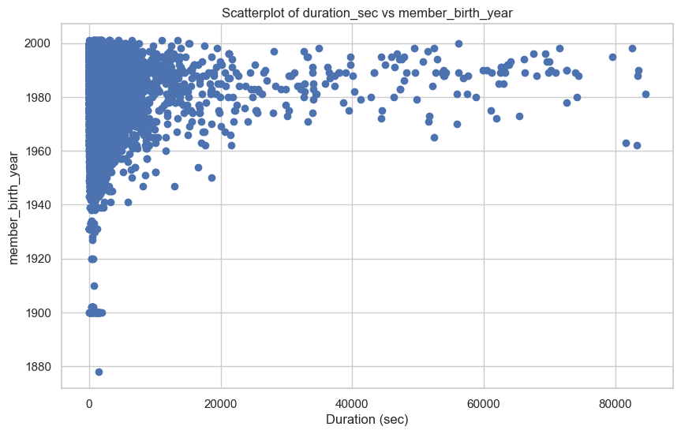

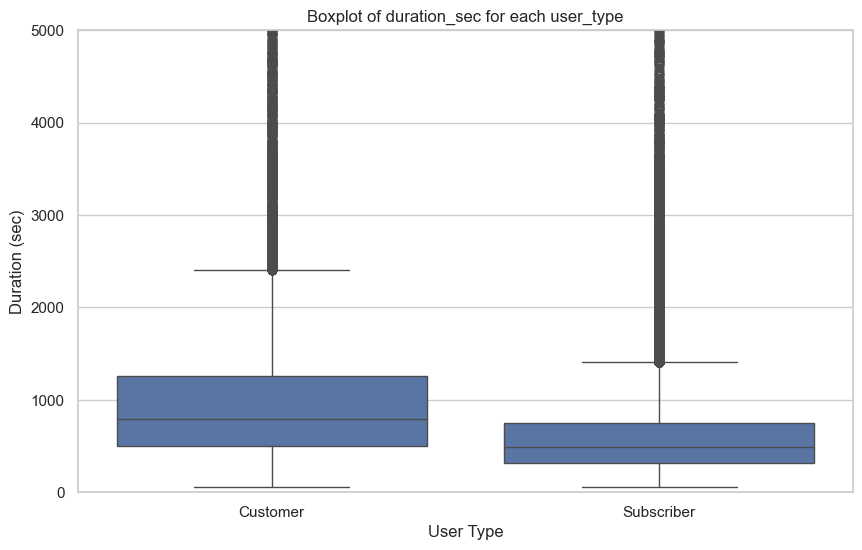

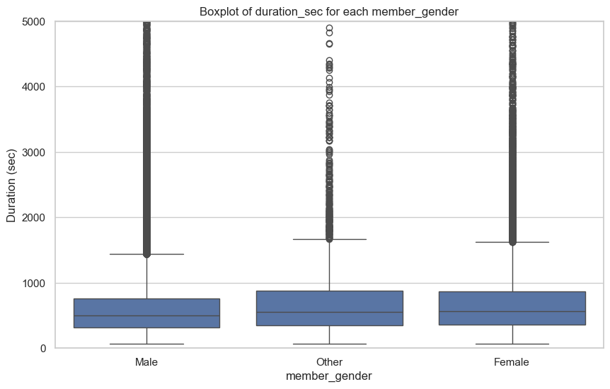

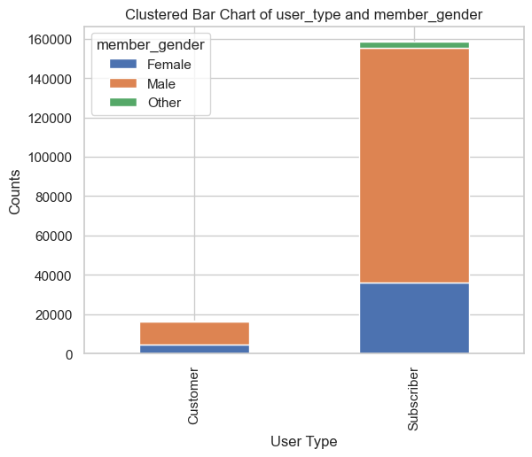

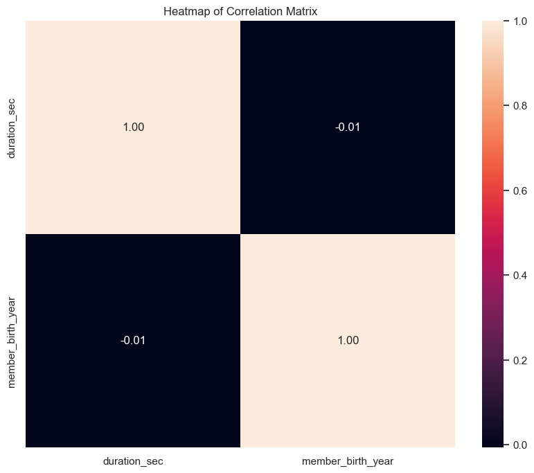

```python
import matplotlib.pyplot as plt
import seaborn as sns

# Scatterplot
plt.figure(figsize=(10,6))
plt.scatter(data = df, x = 'duration_sec', y = 'member_birth_year')
plt.title('Scatterplot of duration_sec vs member_birth_year')
plt.xlabel('Duration (sec)')
plt.ylabel('member_birth_year')
plt.show()

# Boxplot
plt.figure(figsize=(10,6))
sns.boxplot(data = df, x = 'user_type', y = 'duration_sec')
plt.title('Boxplot of duration_sec for each user_type')
plt.xlabel('User Type')
plt.ylabel('Duration (sec)')
plt.ylim([0, 5000]) # Limiting to get a better visualization
plt.show()

plt.figure(figsize=(10,6))
sns.boxplot(data = df, x = 'member_gender', y = 'duration_sec')
plt.title('Boxplot of duration_sec for each member_gender')
plt.xlabel('member_gender')
plt.ylabel('Duration (sec)')
plt.ylim([0, 5000]) # Limiting to get a better visualization
plt.show()

# Clustered Bar Chart
df_grouped = df.groupby(['user_type', 'member_gender']).size().reset_index(name='counts')
pivot_df = df_grouped.pivot(index='user_type', columns='member_gender', values='counts')

pivot_df.plot(kind='bar', stacked=True)
plt.title('Clustered Bar Chart of user_type and member_gender')
plt.xlabel('User Type')
plt.ylabel('Counts')
plt.show()

# Heatmap
# For the heatmap, let's consider the correlation between numerical variables
numerical_vars = ['duration_sec',  'member_birth_year']
corr_matrix = df[numerical_vars].corr()

plt.figure(figsize=(10,8))
sns.heatmap(corr_matrix, annot=True, fmt=".2f")
plt.title('Heatmap of Correlation Matrix')
plt.show()
```

### Talk about some of the relationships you observed in this part of the investigation. How did the feature(s) of interest vary with other features in the dataset?

> No significant correlation is found in this case with the available variables. The only thing that seemed relevant to me is that the subscribers in proportion have shorter times than the customers, since when doing the analysis by gender no significant differences were found.

### Did you observe any interesting relationships between the other features (not the main feature(s) of interest)?

> No

## Multivariate Exploration

> Create plots of three or more variables to investigate your data even further. Make sure that your investigations are justified, and follow from your work in the previous sections.

> **Rubric Tip**: This part (Multivariate Exploration) should include at least one Facet Plot, and one Plot Matrix or Scatterplot with multiple encodings.

> **Rubric Tip**: Think carefully about how you encode variables. Choose appropriate color schemes, markers, or even how Facets are chosen. Also, do not overplot or incorrectly plot ordinal data.

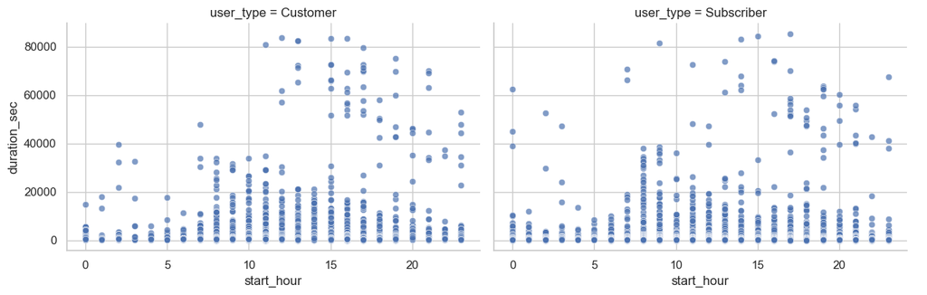

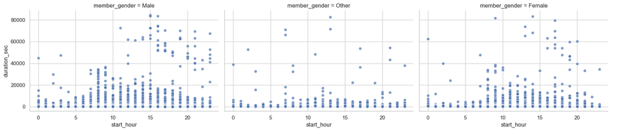

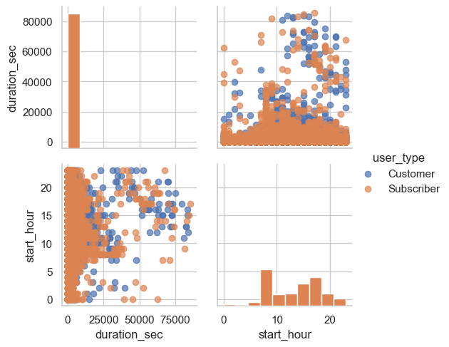

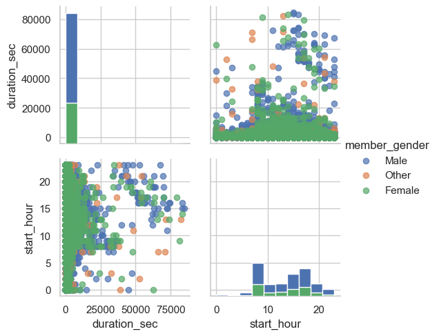

```python
import seaborn as sns
import matplotlib.pyplot as plt
import pandas as pd

# Convertir las columnas de tiempo a datetime
df['start_time'] = pd.to_datetime(df['start_time'])
df['end_time'] = pd.to_datetime(df['end_time'])

# Crear una nueva columna para la hora de inicio
df['start_hour'] = df['start_time'].dt.hour

# FacetGrid
g = sns.FacetGrid(df, col="user_type", height=4, aspect=1.5)
g.map(sns.scatterplot, "start_hour", "duration_sec", alpha=.7)
g.add_legend()
plt.show()

g = sns.FacetGrid(df, col="member_gender", height=4, aspect=1.5)
g.map(sns.scatterplot, "start_hour", "duration_sec", alpha=.7)
g.add_legend()
plt.show()

# PairGrid
g = sns.PairGrid(df, vars=["duration_sec", "start_hour"], hue="user_type")
g.map_diag(plt.hist)
g.map_offdiag(plt.scatter, alpha=.7)
g.add_legend()
plt.show()

g = sns.PairGrid(df, vars=["duration_sec", "start_hour"], hue="member_gender")
g.map_diag(plt.hist)
g.map_offdiag(plt.scatter, alpha=.7)
g.add_legend()
plt.show()
```

### Were there any interesting or surprising interactions between features?

> No

## Conclusions

> You can write a summary of the main findings and reflect on the steps taken during the data exploration.

> **Rubric Tip**: Create a list of summary findings to make it easy to review.

Final conslusions:

Honestly, the conclusions based on the information or data available are not significant, since no correlation is found between age and times, so to speak, everything else is categorical variables and coordinates of the sites.

> Remove all Tips mentioned above, before you convert this notebook to PDF/HTML.

> At the end of your report, make sure that you export the notebook as an html file from the `File > Download as... > HTML or PDF` menu. Make sure you keep track of where the exported file goes, so you can put it in the same folder as this notebook for project submission. Also, make sure you remove all of the quote-formatted guide notes like this one before you finish your report!

```python
# Running this cell will execute a bash command to convert this notebook to an .html file
!python -m nbconvert --to html --output-dir='C:\Users\nicol\Downloads\' Part_I_exploration_template.ipynb
```